# Exercise 01: Primers

Muchen Wang

18 September, 2024

For this first exercise, you will need to clean the Excel file. Your task will be to tidy the data and then read it into Renku’s RStudio.

We have provided a file containing fieldwork metadata from an eDNA sampling mission on the Ogooué River in Gabon. When sampling eDNA in freshwater ecosystems, we collect a volume of water using a peristaltic filtration device and a filter of a specified pore size. The DNA present in the water is trapped in the filter. This DNA will be preserved in a buffer and then extracted in the lab.

All this information is provided in the Excel file. You will find the identification name of each sample (Filter_ID) and various types of parameters related to these samples, such as the sampling date, duration, total volume, and type of buffer (Longmire).

Open the file in Excel and navigate to the tab. You will find a short description in the description sheet. The main issue with this data set is that .xlsx files are not easily readable in R without an extra package. In addition, even after saving the sheet ‘Metadata_field_fw_gb_2024’ as a CSV file, the table you get is not **machine-readable** into a data frame that we can work with in R. The way the data is organised into cells does not follow the structure of a dataframe and is not tidy. Recall the **tidy data** rules from the 01_primers.Rmd tutorial.

Your task is to:

**1. Manually manipulate the .xlsx file to make it tidy.**

**2. Save the data as a .csv file (comma-separated-values).**

**3. Read the .csv file into RStudio.**

```r
# enter your solution here
data <- read.csv("/home/rstudio/work/01-primer/data/Metadata_field_fw_gb_2024.csv")
```

**4. Convert the temperature data that are in kelvin degree into Celsius degree by applying the following formula: T°c = x -273.15°K, and add this new variable to the data set that you have import in R.**

```r
# enter your solution here
data$Temperature..celsius. = data$Temperature..kelvin.-273.15
data$Temperature..celsius.
```

```
##  [1] 34.3 34.3 28.0 28.0 30.0 30.0 33.0 33.0 34.2 34.2 29.5 31.0 31.7 32.0 27.0
## [16] 27.0 30.0 30.0 31.4 31.4 32.0 31.5 27.0 27.4 30.0 32.3 33.5 33.5 35.0 35.0
```

**5. Visualise the distribution of the temperature by using the hist function and save the plot as a .pdf file.**

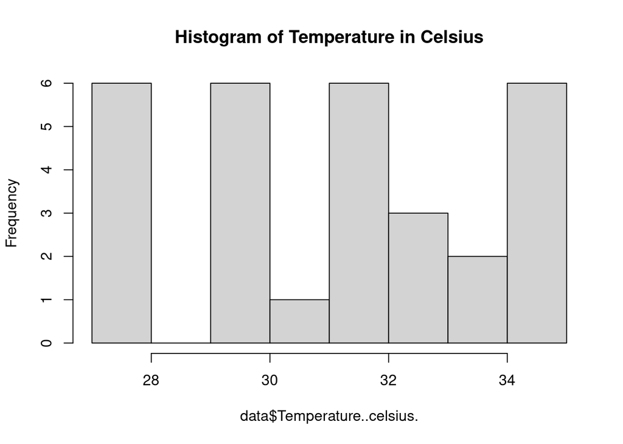

```r
# enter your solution here
hist(data$Temperature..celsius., main = "Histogram of Temperature in Celsius", breaks = 10)
```

```r
pdf("/home/rstudio/work/01-primer/exercise/temp_cel_hist.pdf")
hist(data$Temperature..celsius., main = "Histogram of Temperature in Celsius", breaks = 10)
dev.off()
```

**6. Export the new data frame in csv file.**

```r
# enter your solution here
write.csv(data, "/home/rstudio/work/01-primer/data/n_Metadata_field_fw_gb_2024.csv")
```